# Food Consumption In Indonesia

Atakan Düzgün

## Data on the Cultural Dimension of Urban Community Food Consumption in Indonesia

#### source : https://www.kaggle.com/saurabhshahane/food-consumption-in-indonesia?select=+DATASET+cultural+dimension+of+food+consumption.xlsx

```r
df_all <- read_xlsx("DATASET_cultural dimension of food consumption.xlsx")
```

### Summary of data

This dataset shows survey data on the characteristics of the cultural dimension of food consumption patterns in urban communities in Indonesia. The cultural dimension discussed in this article includes the cultural value and cultural practice sub-dimensions. Data is enriched by illustrating the cultural characteristics of urban people’s food consumption patterns based on social class categories. Data collection was conducted in five major cities of Indonesia with face-to-face interviews with 710 respondents obtained using a stratified random sampling technique.

The results of data show that the cultural dimension is quite dominant in influencing the pattern of food consumption of urban communities in Indonesia compared to the economic and health dimensions. Even though conceptually the value and practice sub-dimensions are integrally related, the cultural dimension of food consumption patterns in urban communities are still more dominated by the value sub-dimension. In the food consumption pattern, the urban upper classes are more dominantly influenced by economic dimensions and modern healthy lifestyles than cultural dimensions.

```r
summary(df_all)
```

```
##   (A1) CITY         (A2) PROVINCE      (B3) GENDER           (B4) AGE
##  Length:710         Length:710         Length:710         Min.   :22.00
##  Class :character   Class :character   Class :character   1st Qu.:31.00
##  Mode  :character   Mode  :character   Mode  :character   Median :39.00
##                                                           Mean   :41.31
##                                                           3rd Qu.:52.00
##                                                           Max.   :65.00
##  (B5) RELIGION      (B6) ETHNIC        (B7) EDUCATION LEVEL
##  Length:710         Length:710         Length:710
##  Class :character   Class :character   Class :character
##  Mode  :character   Mode  :character   Mode  :character
##
##
##
##  (B8) LIVED IN URBAN AREA (YEARS) (B9) OCCUPATION    (B10) SOCIAL CLAS
##  Min.   : 6.00                    Length:710         Length:710
##  1st Qu.:23.00                    Class :character   Class :character
##  Median :29.00                    Mode  :character   Mode  :character
##  Mean   :28.65
##  3rd Qu.:34.00
##  Max.   :63.00
##  (B11) HOUSEHOLD MEMBER (C12) HOUSEHOLD INCOME (MONTHLY IN MILLION IDR)
##  Min.   :5.000          Min.   :1899-12-31 02:03:00
##  1st Qu.:6.000          1st Qu.:1899-12-31 03:04:15
##  Median :6.000          Median :1899-12-31 05:08:00
##  Mean   :6.023          Mean   :1899-12-31 06:13:58
##  3rd Qu.:6.000          3rd Qu.:1899-12-31 10:01:00
##  Max.   :8.000          Max.   :1899-12-31 15:07:00
##  (C13) TIME OF INCOME RECEIPT
##  Length:710
##  Class :character
##  Mode  :character
##
##
##
##  (C14) HOUSEHOLD EXPENDITURE (MONTHLY IN MILLION IDR)
##  Min.   :1899-12-31 01:09:00
##  1st Qu.:1899-12-31 03:03:00
##  Median :1899-12-31 05:05:00
##  Mean   :1899-12-31 06:04:35
```

[output cut: 57 more lines]

```
##
##  (E27 TYPE OF DISHES VARIATION BASED ON RELIGIOUS RULES
##  Length:710
##  Class :character
##  Mode  :character
##
##
##
##  (E28) PRACTICE OF CONSUMING TRADITIONAL FOOD
##  Length:710
##  Class :character
##  Mode  :character
##
##
##
```

#### There are 28 variables, each consisting of 710 observations.

```r
df <- df_all[,c("(B10) SOCIAL CLAS","(C15) % MONTHLY EXPENDITURE FOR FOOD","(B7) EDUCATION LEVEL",
                "(B9) OCCUPATION","(A2) PROVINCE","(B3) GENDER","(B4) AGE")]
```

#### I collected the variables we were interested in in the “df” data, eliminated the other variables

```r
# factor assignments

df$`(A2) PROVINCE` <- as.factor(df$`(A2) PROVINCE`)
df$`(B7) EDUCATION LEVEL` <- as.factor(df$`(B7) EDUCATION LEVEL`)
df$`(B9) OCCUPATION` <- as.factor(df$`(B9) OCCUPATION`)
df$`(B10) SOCIAL CLAS` <- as.factor(df$`(B10) SOCIAL CLAS`)
df$`(C15) % MONTHLY EXPENDITURE FOR FOOD`<- as.integer(df$`(C15) % MONTHLY EXPENDITURE FOR FOOD`)
df$`(B3) GENDER` <- as.factor(df$`(B3) GENDER`)
```

#### Some of its variables were in the wrong class category, I changed the class of the variables to “factor” to continue my analysis.

```r
levels(df$`(B10) SOCIAL CLAS`)
```

```
## [1] "Lower Class"  "Middle Class" "Upper Class"
```

```r
levels(df$`(B7) EDUCATION LEVEL`)
```

```
## [1] "Bachelor degree"            "Diploma"
## [3] "Junior High School"         "Master and doctoral degree"
## [5] "Primary School"             "Senior High School"
```

```r
levels(df$`(B9) OCCUPATION`)
```

```
## [1] "Enterpreneur"         "Government Employees" "Independent Worker"
## [4] "Police Officer/Army" "Private Employees"    "Teacher/Lecturer"
```

```r
levels(df$`(A2) PROVINCE`)
```

```
## [1] "Bali"           "DKI Jakarta"    "East Java"      "South Sulawesi"
## [5] "West Java"
```

```r
levels(df$`(B3) GENDER`)
```

```
## [1] "Female" "Male"
```

#### The amount of Na in the data is checked

```r
sum(is.na(df$`(B10) SOCIAL CLAS`))
```

```
## [1] 0
```

```r
sum(is.na(df$`(C15) % MONTHLY EXPENDITURE FOR FOOD`))
```

```
## [1] 0
```

```r
sum(is.na(df$`(B7) EDUCATION LEVEL`))
```

```
## [1] 0
```

```r
sum(is.na(df$`(B9) OCCUPATION`))
```

```
## [1] 0
```

```r
sum(is.na(df$`(A2) PROVINCE`))
```

```
## [1] 0
```

```r
sum(is.na(df$`(B3) GENDER`))
```

```
## [1] 0
```

```r
sum(is.na(df$`(B4) AGE`))
```

```
## [1] 0
```

#### There is no Na observation in the data.

#### Summary of df

```r
summary(df)
```

```
##     (B10) SOCIAL CLAS (C15) % MONTHLY EXPENDITURE FOR FOOD
##  Lower Class :246     Min.   :18.00
##  Middle Class:256     1st Qu.:26.00
##  Upper Class :208     Median :41.00
##                       Mean   :42.99
##                       3rd Qu.:58.00
##                       Max.   :76.00
##                  (B7) EDUCATION LEVEL                    (B9) OCCUPATION
##  Bachelor degree           :212       Enterpreneur               :193
##  Diploma                   :156       Government Employees       :202
##  Junior High School        : 37       Independent Worker         : 60
##  Master and doctoral degree:100       Police Officer/Army: 30
##  Primary School            : 24       Private Employees          :205
##  Senior High School        :181       Teacher/Lecturer   : 20
##         (A2) PROVINCE (B3) GENDER     (B4) AGE
##  Bali          :148   Female:411   Min.   :22.00
##  DKI Jakarta   :174   Male  :299   1st Qu.:31.00
##  East Java     :118                Median :39.00
##  South Sulawesi:120                Mean   :41.31
##  West Java     :150                3rd Qu.:52.00
##                                    Max.   :65.00
```

#### Boxplot graph visualizing the distribution of the “Social Class” variable chosen as the main factor over the “% Monthly Expenditure For Food” variable

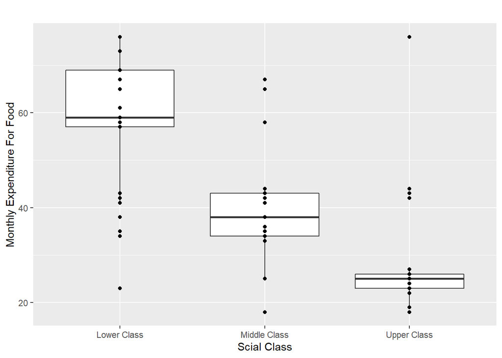